# CSCI441(MH)

Diamond Price Prediction

Presented by : Muhyiddin Hamad(92220006) Hadi Khoder(92230520)

CSCI441(Machine Learning)

Instructor: Dr.Maher Abdulrahman

Table of Contents

1. Introduction 1.1 Project Background 1.2 Problem Statement 1.3 Project Objectives
2. Dataset Description 2.1 Dataset Source 2.2 Dataset Features (Attributes) 2.3 Data Types and Size
3. Exploratory Data Analysis (EDA) 3.1 Data Overview 3.2 Statistical Summary 3.3 Data Visualization
4. Data Preprocessing 4.1 Handling Missing Values 4.2 Encoding Categorical Variables 4.3 Feature Scaling
5. Machine Learning Models 5.1 Linear Regression 5.2 Decision Tree Regressor 5.3 Random Forest Regressor 5.4 Gradient Boosting Regressor 5.5 Support Vector Regression (SVR)
6. Model Evaluation 6.1 Performance Metrics 6.2 Model Comparison
7. Results and Discussion
8. Conclusion
1. Introduction

1.1 Project Background Diamonds are priced based on multiple characteristics such as carat weight, cut quality, color grade, clarity, and physical dimensions. Because many factors affect the final price, predicting diamond prices manually can be difficult and inconsistent. Machine Learning can learn patterns from historical diamond data and estimate the price of a diamond more accurately and faster. Why this matters: It helps buyers, sellers, and businesses estimate fair prices and make better decisions.

1.2 Problem Statement The problem is to build a model that can predict the price of a diamond using its features (carat, cut, color, clarity, depth, table, and dimensions). The goal is to reduce pricing uncertainty by using data-driven prediction.

1.3 Project Objectives • Understand the diamond dataset and its attributes • Perform Exploratory Data Analysis (EDA) to find relationships with price • Preprocess the data (handle categorical variables + scaling if needed) • Train regression machine learning models to predict diamond price • Evaluate and compare models using appropriate regression metrics • Select the best model and summarize results

2. Dataset Description

2.1 Dataset Source The dataset used in this project is the Diamonds Dataset, which is publicly available on Kaggle. This dataset is widely used in machine learning projects, especially for regression tasks. It contains real-world data describing the characteristics of diamonds and their corresponding prices. The dataset includes information for more than 150,000 diamonds, making it suitable for training and evaluating machine learning models.

2.2 Dataset Features

```python
import pandas as pd
```

```python
import os
os.getcwd()
```

```
'c:\\Users\\Pc\\Downloads'
```

```python
import os
os.chdir(r"C:\Users\Pc\Downloads")
```

```python
import pandas as pd
df = pd.read_csv("diamonds.csv")
```

```python
df = df.drop(columns=["Unnamed: 0"])
```

```python
df.head()
```

[output not shown]

2.3 Data Size and Data Types

dataset diemention:

```python
df.shape
```

```
(219703, 25)
```

Detailed information about the dataset:

```python
df.info()
```

```
<class 'pandas.core.frame.DataFrame'>
RangeIndex: 219703 entries, 0 to 219702
Data columns (total 25 columns):
 #   Column                       Non-Null Count   Dtype
---  ------                       --------------   -----
 0   cut                          219703 non-null  object
 1   color                        219703 non-null  object
 2   clarity                      219703 non-null  object
 3   carat_weight                 219703 non-null  float64
 4   cut_quality                  219703 non-null  object
 5   lab                          219703 non-null  object
 6   symmetry                     219703 non-null  object
 7   polish                       219703 non-null  object
 8   eye_clean                    219703 non-null  object
 9   culet_size                   219703 non-null  object
```

[output cut: 17 more lines]

The first five rows:

```python
df.head()
```

|  | cut | color | clarity | carat_weight | cut_quality | lab | symmetry | polish | eye_clean | culet_size | ... | meas_depth | girdle_min | girdle_max | fluor_color | fluor_intensity | fancy_color_dominant_color | fancy_color_secondary_color | fancy_color_overtone | fancy_color_intensity | total_sales_price |
| --- | --- | --- | --- | --- | --- | --- | --- | --- | --- | --- | --- | --- | --- | --- | --- | --- | --- | --- | --- | --- | --- |
| 0 | Round | E | VVS2 | 0.09 | Excellent | IGI | Very Good | Very Good | unknown | N | ... | 1.79 | M | M | unknown | Unknown | unknown | unknown | unknown | unknown | 200 |
| 1 | Round | E | VVS2 | 0.09 | Very Good | IGI | Very Good | Very Good | unknown | N | ... | 1.78 | STK | STK | unknown | Unknown | unknown | unknown | unknown | unknown | 200 |
| 2 | Round | E | VVS2 | 0.09 | Excellent | IGI | Very Good | Very Good | unknown | unknown | ... | 1.77 | TN | M | unknown | Unknown | unknown | unknown | unknown | unknown | 200 |
| 3 | Round | E | VVS2 | 0.09 | Excellent | IGI | Very Good | Very Good | unknown | unknown | ... | 1.78 | M | STK | unknown | Unknown | unknown | unknown | unknown | unknown | 200 |
| 4 | Round | E | VVS2 | 0.09 | Very Good | IGI | Very Good | Excellent | unknown | N | ... | 1.82 | STK | STK | unknown | Unknown | unknown | unknown | unknown | unknown | 200 |

5 rows × 25 columns

Check for missing values:

```python
df.isnull().sum()
```

```
cut                            0
color                          0
clarity                        0
carat_weight                   0
cut_quality                    0
lab                            0
symmetry                       0
polish                         0
eye_clean                      0
culet_size                     0
culet_condition                0
depth_percent                  0
table_percent                  0
meas_length                    0
meas_width                     0
meas_depth                     0
girdle_min                     0
girdle_max                     0
fluor_color                    0
fluor_intensity                0
fancy_color_dominant_color     0
fancy_color_secondary_color    0
fancy_color_overtone           0
fancy_color_intensity          0
total_sales_price              0
dtype: int64
```

Display staticaly summry of numerical features:

```python
df.describe()
```

|  | carat_weight | depth_percent | table_percent | meas_length | meas_width | meas_depth | total_sales_price |
| --- | --- | --- | --- | --- | --- | --- | --- |
| count | 219703.000000 | 219703.000000 | 219703.000000 | 219703.000000 | 219703.000000 | 219703.000000 | 2.197030e+05 |
| mean | 0.755176 | 61.683768 | 57.747585 | 5.548853 | 5.135626 | 3.285699 | 6.908062e+03 |
| std | 0.845894 | 9.915266 | 9.959928 | 1.763924 | 1.374529 | 2.054822 | 2.595949e+04 |
| min | 0.080000 | 0.000000 | 0.000000 | 0.000000 | 0.000000 | 0.000000 | 2.000000e+02 |
| 25% | 0.310000 | 61.200000 | 57.000000 | 4.350000 | 4.310000 | 2.680000 | 9.580000e+02 |
| 50% | 0.500000 | 62.400000 | 58.000000 | 5.060000 | 4.800000 | 3.030000 | 1.970000e+03 |
| 75% | 1.000000 | 63.500000 | 60.000000 | 6.350000 | 5.700000 | 3.630000 | 5.207000e+03 |
| max | 19.350000 | 98.700000 | 94.000000 | 93.660000 | 62.300000 | 76.300000 | 1.449881e+06 |

3.1 Data Overview:

In this section, the dataset is inspected to understand its structure, data types, and basic content. We display the first rows of the dataset, check the number of rows and columns, and review the column data types. This provides an initial understanding of the data before performing deeper analysis.

3.2 Statistical Summary:

The statistical summary provides descriptive statistics for numerical features such as mean, standard deviation, minimum, maximum, and quartiles. This helps identify the general distribution of values and detect potential outliers that may affect the modeling stage.

3.3.1 Price Distribution:

1:Distribution of diamond prices. Most diamonds are concentrated in lower price ranges, while fewer diamonds have very high prices, indicating a right-skewed distribution.

```python
df.columns
```

```
Index(['cut', 'color', 'clarity', 'carat_weight', 'cut_quality', 'lab',
       'symmetry', 'polish', 'eye_clean', 'culet_size', 'culet_condition',
       'depth_percent', 'table_percent', 'meas_length', 'meas_width',
       'meas_depth', 'girdle_min', 'girdle_max', 'fluor_color',
       'fluor_intensity', 'fancy_color_dominant_color',
       'fancy_color_secondary_color', 'fancy_color_overtone',
       'fancy_color_intensity', 'total_sales_price'],
      dtype='object')
```

```python
import pandas as pd
import matplotlib.pyplot as plt
```

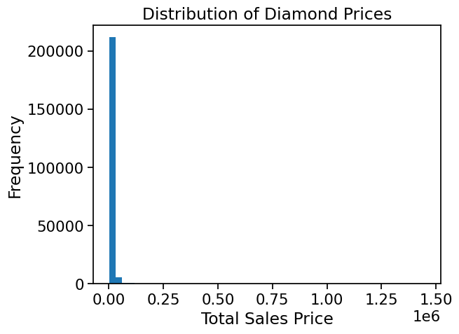

```python
plt.figure()
plt.hist(df['total_sales_price'], bins=50)
plt.xlabel('Total Sales Price')
plt.ylabel('Frequency')
plt.title('Distribution of Diamond Prices')
plt.show()
```

2:Count plots are used to visualize the distribution of categorical variables. These plots show the frequency of each category and help identify dominant and less frequent classes in the dataset.

```python
import seaborn as sns
```

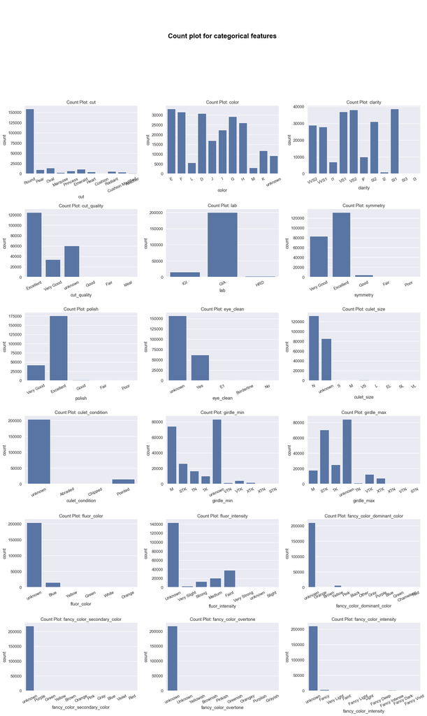

```python
import math
import matplotlib.pyplot as plt
import seaborn as sns

# 1) Define categorical columns for diamonds (or auto-detect them)
cat_cols = df.select_dtypes(include="object").columns.tolist()
# For diamonds, this will become: ['cut', 'color', 'clarity']

# 2) Grid size depends on number of categorical columns
n = len(cat_cols)
cols = 3                           # number of plots per row
rows = math.ceil(n / cols)

fig = plt.figure(figsize=(18, 5 * rows))
gs = fig.add_gridspec(rows + 1, cols)  # +1 row for the title box (ax0)

# Title box (like your original)
ax0 = fig.add_subplot(gs[0, :])
ax0.tick_params(left=False, bottom=False)
ax0.set_xticklabels([])
ax0.set_yticklabels([])
ax0.text(
    0.5, 0.5,
    s="Count plot for categorical features",
    horizontalalignment='center',
    verticalalignment='center',
    fontsize=20, fontweight='bold'
)

# Hide title box spines
for s in ["top", "right", "left", "bottom"]:
    ax0.spines[s].set_visible(False)

# 3) Plot each categorical column automatically
sns.set(font_scale=1.1)

for i, col in enumerate(cat_cols):
    r = (i // cols) + 1
    c = (i % cols)
    ax = fig.add_subplot(gs[r, c])
    sns.countplot(data=df, x=col, ax=ax)
    ax.set_title(f"Count Plot: {col}")

    # Make labels readable
    ax.tick_params(axis='x', rotation=25)

    # Remove spines like your original
    for s in ["top", "right", "left"]:
        ax.spines[s].set_visible(False)

plt.tight_layout()
plt.show()
```

3:Relationship between carat weight and total_sales_price

A strong positive relationship appears between carat and total_sales_price, meaning price generally increases as carat increases.

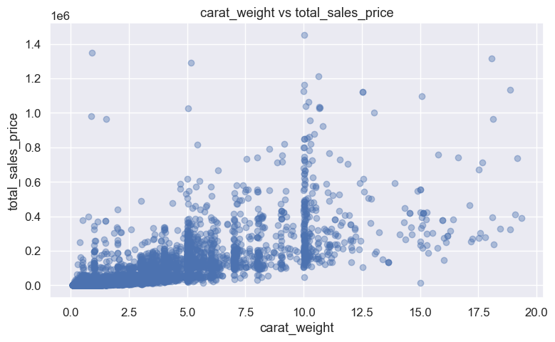

```python
plt.figure(figsize=(8,5))
plt.scatter(df["carat_weight"], df["total_sales_price"], alpha=0.4)
plt.xlabel("carat_weight")
plt.ylabel("total_sales_price")
plt.title("carat_weight vs total_sales_price")
plt.tight_layout()
plt.show()
```

4: Count plots for categorical features (cut, color, clarity). These plots show how diamonds are distributed across cut, color, and clarity categories.

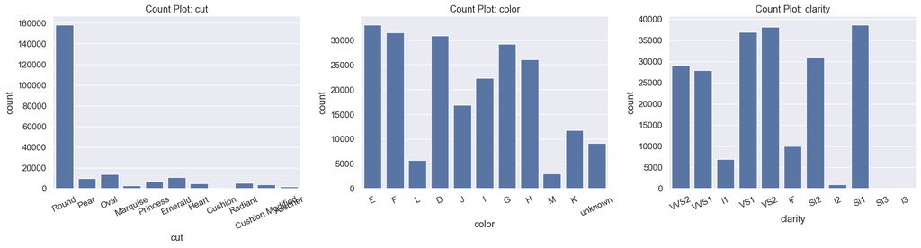

```python
cat_cols = ["cut", "color", "clarity"]

fig, axes = plt.subplots(1, 3, figsize=(18,5))
for ax, col in zip(axes, cat_cols):
    sns.countplot(data=df, x=col, ax=ax)
    ax.set_title(f"Count Plot: {col}")
    ax.tick_params(axis='x', rotation=25)
    for s in ["top","right","left"]:
        ax.spines[s].set_visible(False)

plt.tight_layout()
plt.show()
```

5: total_sales_price by Cut

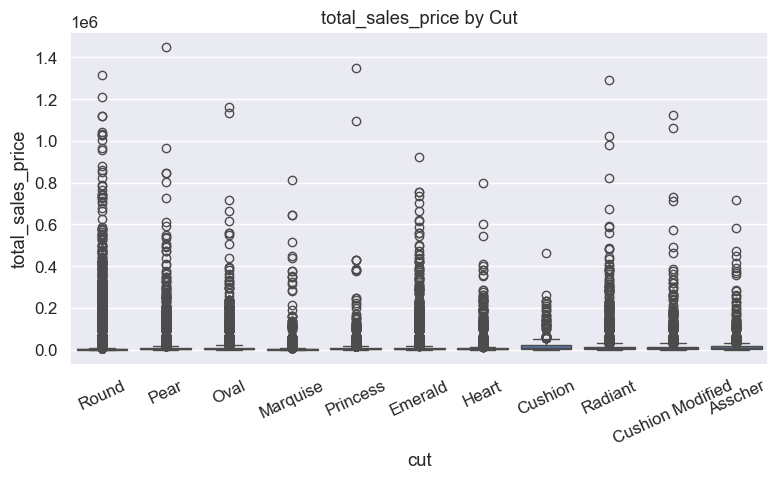

```python
plt.figure(figsize=(8,5))
sns.boxplot(data=df, x="cut", y="total_sales_price")
plt.title("total_sales_price by Cut")
plt.xticks(rotation=25)
plt.tight_layout()
plt.show()
```

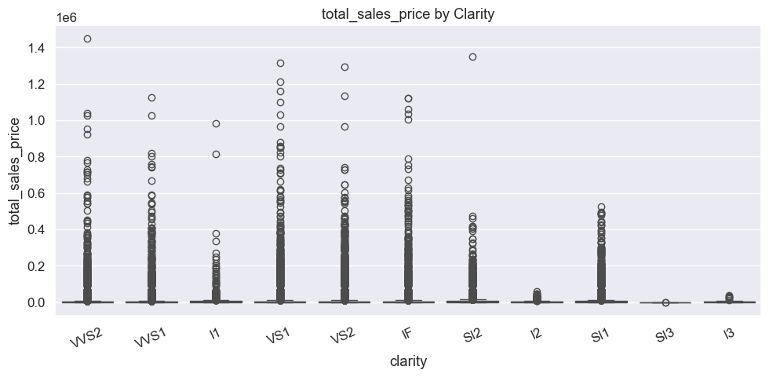

```python
plt.figure(figsize=(10,5))
sns.boxplot(data=df, x="clarity", y="total_sales_price")
plt.title("total_sales_price by Clarity")
plt.xticks(rotation=25)
plt.tight_layout()
plt.show()
```

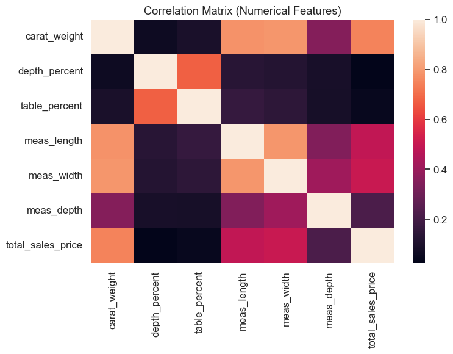

```python
import numpy as np
num_df = df.select_dtypes(include=[np.number])
corr = num_df.corr()

plt.figure(figsize=(8,6))
sns.heatmap(corr, annot=False)
plt.title("Correlation Matrix (Numerical Features)")
plt.tight_layout()
plt.show()
```

8: The boxen plot shows that the total sales price is highly right-skewed. Most observations are concentrated near lower values, while a small number of observations have very large values, indicating the presence of outliers.

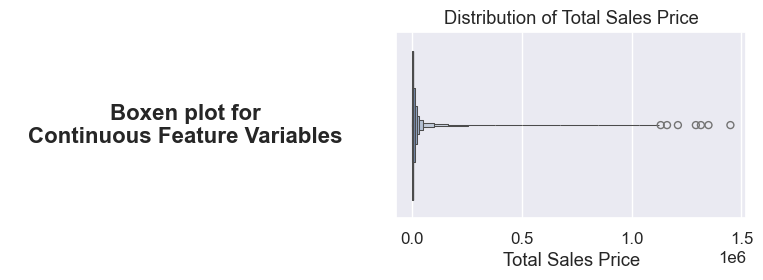

```python
fig = plt.figure(figsize=(8,3))
gs = fig.add_gridspec(1,2)

# Left text box
ax0 = fig.add_subplot(gs[0,0])
ax0.axis("off")
ax0.text(
    0.5, 0.5,
    "Boxen plot for\nContinuous Feature Variables",
    ha="center", va="center",
    fontsize=16, fontweight="bold"
)

# Right plot
ax1 = fig.add_subplot(gs[0,1])
sns.boxenplot(x=df["total_sales_price"], ax=ax1)
ax1.set_xlabel("Total Sales Price")
ax1.set_title("Distribution of Total Sales Price")

plt.tight_layout()
plt.show()
```

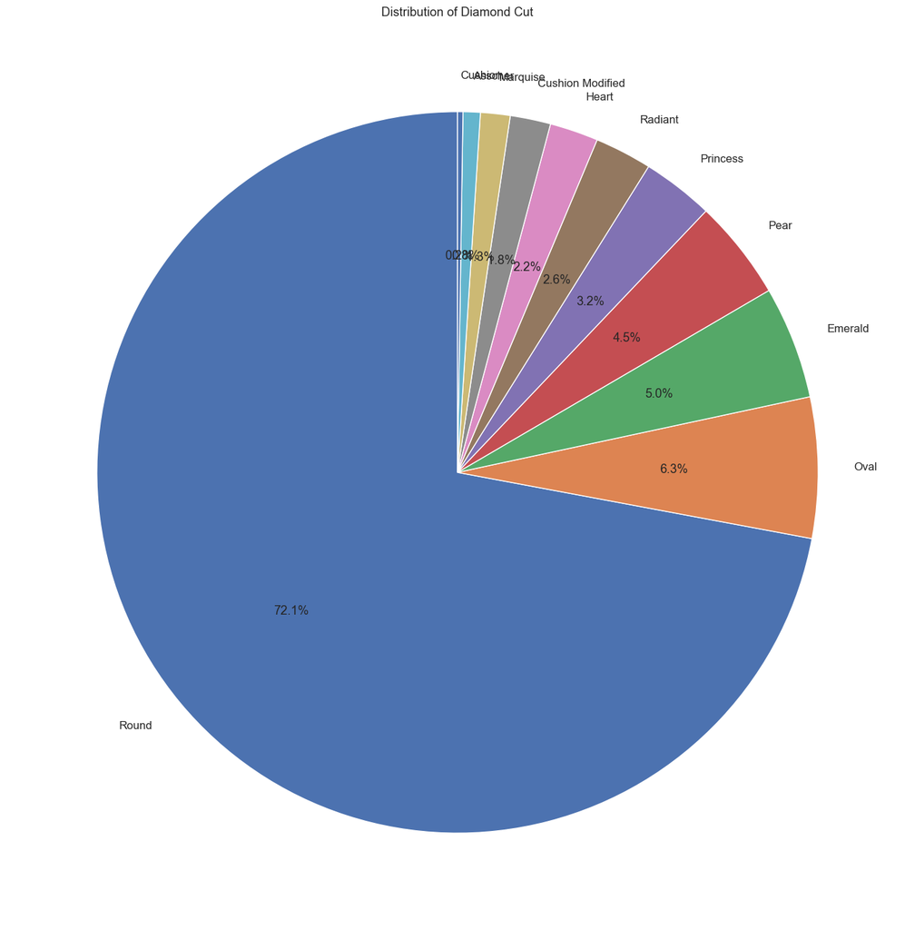

```python
plt.figure(figsize=(14,14))
df["cut"].value_counts().plot.pie(
    autopct='%1.1f%%',
    startangle=90
)
plt.title("Distribution of Diamond Cut")
plt.ylabel("")
plt.tight_layout()
plt.show()
```

10: The figure illustrates the distribution of diamond color grades in the dataset, showing the relative frequency of each color category.

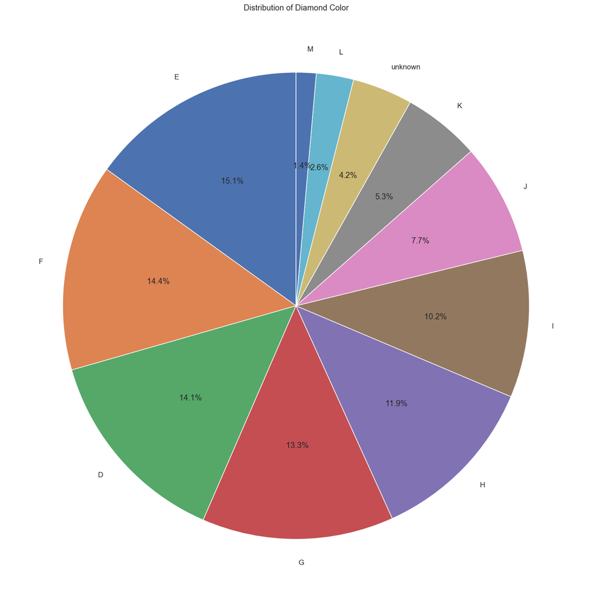

```python
plt.figure(figsize=(14,14))
df["color"].value_counts().plot.pie(
    autopct='%1.1f%%',
    startangle=90
)
plt.title("Distribution of Diamond Color")
plt.ylabel("")
plt.tight_layout()
plt.show()
```

11:The figure illustrates the Distribution of Diamond Clarity.

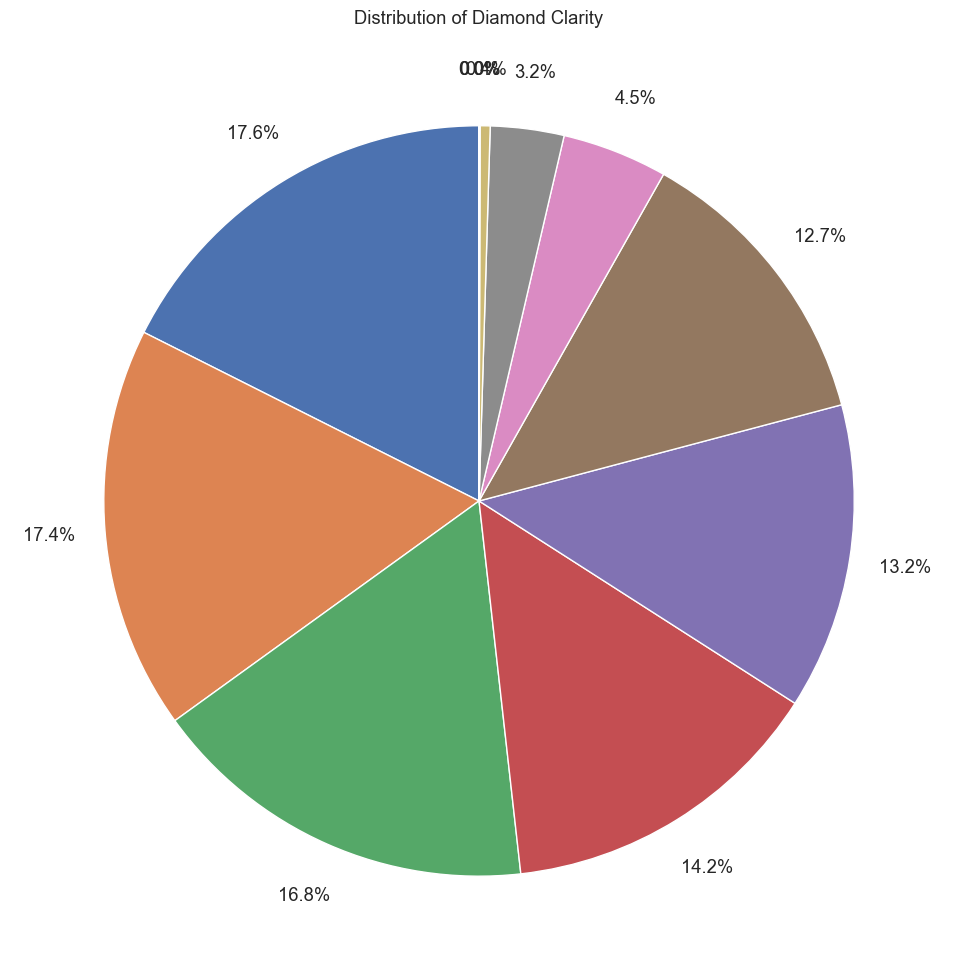

```python
plt.figure(figsize=(10,10))
df["clarity"].value_counts().plot.pie(
    autopct='%1.1f%%',
    startangle=90,
    pctdistance=1.15,
    labeldistance=1.3,
    labels=None
)
plt.title("Distribution of Diamond Clarity")
plt.ylabel("")
plt.tight_layout()
plt.show()
```

4.Data Preprocessing Short Explanation: Data preprocessing is a crucial step in machine learning that prepares raw data for model training. In this phase, the dataset is cleaned and transformed to ensure that machine learning algorithms can process it correctly. This includes handling missing values, converting categorical variables into numerical form, and scaling numerical features so that all variables are on a similar scale.

4.1 : Handling Missing Values Missing values can negatively affect machine learning models. Therefore, it is important to detect and handle them before training. Numerical missing values are replaced using the median, while categorical missing values are replaced using the most frequent category.

4.1.1: Check for Missing Values

```python
df.isnull().sum()
```

```
cut                            0
color                          0
clarity                        0
carat_weight                   0
cut_quality                    0
lab                            0
symmetry                       0
polish                         0
eye_clean                      0
culet_size                     0
culet_condition                0
depth_percent                  0
table_percent                  0
meas_length                    0
meas_width                     0
meas_depth                     0
girdle_min                     0
girdle_max                     0
fluor_color                    0
fluor_intensity                0
fancy_color_dominant_color     0
fancy_color_secondary_color    0
fancy_color_overtone           0
fancy_color_intensity          0
total_sales_price              0
dtype: int64
```

4.1.2: Fill Missing Values:

```python
# Separate numeric and categorical columns
num_cols = df.select_dtypes(include="number").columns.tolist()
cat_cols = df.select_dtypes(include="object").columns.tolist()

# Fill numeric columns with median
for col in num_cols:
    df[col] = df[col].fillna(df[col].median())

# Fill categorical columns with mode
for col in cat_cols:
    df[col] = df[col].fillna(df[col].mode()[0])

# Verify no missing values remain
df.isnull().sum().sum()
```

```
np.int64(0)
```

4.2 Encoding Categorical Variables Explanation:

Machine learning algorithms require numerical input. Therefore, categorical (text) variables must be converted into numerical format. One-Hot Encoding is used to transform each category into a binary feature.

## data cleaning:

```python
for col in df.select_dtypes(include="object").columns:
    df[col] = df[col].fillna("Unknown")
```

4.2.1: Define Features and Target

```python
target = "total_sales_price"   # target variable
X = df.drop(columns=[target])
y = df[target]
```

4.2.2: Apply One-Hot Encoding

```python
from sklearn.model_selection import train_test_split

X_train, X_test, y_train, y_test = train_test_split(
    X, y, test_size=0.2, random_state=42
)
```

```python
X_train = pd.get_dummies(X_train, drop_first=True)
X_test = pd.get_dummies(X_test, drop_first=True)

X_train, X_test = X_train.align(
    X_test, join="left", axis=1, fill_value=0
)
```

```python
X_encoded = pd.get_dummies(X, drop_first=True)
X_encoded.head()
```

|  | carat_weight | depth_percent | table_percent | meas_length | meas_width | meas_depth | cut_Cushion | cut_Cushion Modified | cut_Emerald | cut_Heart | ... | fancy_color_overtone_unknown | fancy_color_intensity_Fancy | fancy_color_intensity_Fancy Dark | fancy_color_intensity_Fancy Deep | fancy_color_intensity_Fancy Intense | fancy_color_intensity_Fancy Light | fancy_color_intensity_Fancy Vivid | fancy_color_intensity_Light | fancy_color_intensity_Very Light | fancy_color_intensity_unknown |
| --- | --- | --- | --- | --- | --- | --- | --- | --- | --- | --- | --- | --- | --- | --- | --- | --- | --- | --- | --- | --- | --- |
| 0 | 0.09 | 62.7 | 59.0 | 2.85 | 2.87 | 1.79 | False | False | False | False | ... | True | False | False | False | False | False | False | False | False | True |
| 1 | 0.09 | 61.9 | 59.0 | 2.84 | 2.89 | 1.78 | False | False | False | False | ... | True | False | False | False | False | False | False | False | False | True |
| 2 | 0.09 | 61.1 | 59.0 | 2.88 | 2.90 | 1.77 | False | False | False | False | ... | True | False | False | False | False | False | False | False | False | True |
| 3 | 0.09 | 62.0 | 59.0 | 2.86 | 2.88 | 1.78 | False | False | False | False | ... | True | False | False | False | False | False | False | False | False | True |
| 4 | 0.09 | 64.9 | 58.5 | 2.79 | 2.83 | 1.82 | False | False | False | False | ... | True | False | False | False | False | False | False | False | False | True |

5 rows × 135 columns

4.3 Feature Scaling Explanation Feature scaling ensures that numerical variables have similar ranges. This is especially important for algorithms such as Support Vector Regression (SVR) and Linear Regression, which are sensitive to feature scale.

4.3.1: Train–Test Split

```python
from sklearn.model_selection import train_test_split

X_train, X_test, y_train, y_test = train_test_split(
    X_encoded, y, test_size=0.2, random_state=42
)
```

4.3.2: Apply Standard Scaling

```python
from sklearn.preprocessing import StandardScaler

scaler = StandardScaler()

X_train_scaled = scaler.fit_transform(X_train)
X_test_scaled  = scaler.transform(X_test)
X_encoded.head(5)
```

|  | carat_weight | depth_percent | table_percent | meas_length | meas_width | meas_depth | cut_Cushion | cut_Cushion Modified | cut_Emerald | cut_Heart | ... | fancy_color_overtone_unknown | fancy_color_intensity_Fancy | fancy_color_intensity_Fancy Dark | fancy_color_intensity_Fancy Deep | fancy_color_intensity_Fancy Intense | fancy_color_intensity_Fancy Light | fancy_color_intensity_Fancy Vivid | fancy_color_intensity_Light | fancy_color_intensity_Very Light | fancy_color_intensity_unknown |
| --- | --- | --- | --- | --- | --- | --- | --- | --- | --- | --- | --- | --- | --- | --- | --- | --- | --- | --- | --- | --- | --- |
| 0 | 0.09 | 62.7 | 59.0 | 2.85 | 2.87 | 1.79 | False | False | False | False | ... | True | False | False | False | False | False | False | False | False | True |
| 1 | 0.09 | 61.9 | 59.0 | 2.84 | 2.89 | 1.78 | False | False | False | False | ... | True | False | False | False | False | False | False | False | False | True |
| 2 | 0.09 | 61.1 | 59.0 | 2.88 | 2.90 | 1.77 | False | False | False | False | ... | True | False | False | False | False | False | False | False | False | True |
| 3 | 0.09 | 62.0 | 59.0 | 2.86 | 2.88 | 1.78 | False | False | False | False | ... | True | False | False | False | False | False | False | False | False | True |
| 4 | 0.09 | 64.9 | 58.5 | 2.79 | 2.83 | 1.82 | False | False | False | False | ... | True | False | False | False | False | False | False | False | False | True |

5 rows × 135 columns

```python
from sklearn.preprocessing import StandardScaler

scaler = StandardScaler()

X_train_scaled = scaler.fit_transform(X_train)
X_test_scaled = scaler.transform(X_test)

X_train_scaled_df = pd.DataFrame(
    X_train_scaled,
    columns=X_train.columns,
    index=X_train.index
)
```

Creating a Pandas DataFrame from Scaled Training Data

```python
X_train_scaled_df = pd.DataFrame(
    X_train_scaled,
    columns=X_train.columns,
    index=X_train.index
)

X_train_scaled_df.head()
```

|  | carat_weight | depth_percent | table_percent | meas_length | meas_width | meas_depth | cut_Cushion | cut_Cushion Modified | cut_Emerald | cut_Heart | ... | fancy_color_overtone_unknown | fancy_color_intensity_Fancy | fancy_color_intensity_Fancy Dark | fancy_color_intensity_Fancy Deep | fancy_color_intensity_Fancy Intense | fancy_color_intensity_Fancy Light | fancy_color_intensity_Fancy Vivid | fancy_color_intensity_Light | fancy_color_intensity_Very Light | fancy_color_intensity_unknown |
| --- | --- | --- | --- | --- | --- | --- | --- | --- | --- | --- | --- | --- | --- | --- | --- | --- | --- | --- | --- | --- | --- |
| 34255 | -0.645175 | 0.041372 | 0.024182 | -0.970796 | -0.925049 | -0.435214 | -0.049117 | -0.136003 | -0.230306 | -0.148434 | ... | 0.096361 | -0.126331 | -0.032723 | -0.05916 | -0.09512 | -0.07659 | -0.05759 | -0.037438 | -0.030561 | 0.208805 |
| 33445 | -0.538654 | 0.253673 | 0.124922 | -0.784316 | -0.678384 | -0.294245 | -0.049117 | -0.136003 | -0.230306 | -0.148434 | ... | 0.096361 | -0.126331 | -0.032723 | -0.05916 | -0.09512 | -0.07659 | -0.05759 | -0.037438 | -0.030561 | 0.208805 |
| 100701 | -0.290106 | 0.738932 | 0.729364 | -0.207923 | -0.837991 | -0.265079 | -0.049117 | -0.136003 | -0.230306 | -0.148434 | ... | 0.096361 | -0.126331 | -0.032723 | -0.05916 | -0.09512 | -0.07659 | -0.05759 | -0.037438 | -0.030561 | 0.208805 |
| 158452 | -0.183585 | 0.041372 | 0.024182 | -0.083603 | 0.213962 | 0.036304 | -0.049117 | -0.136003 | -0.230306 | -0.148434 | ... | 0.096361 | -0.126331 | -0.032723 | -0.05916 | -0.09512 | -0.07659 | -0.05759 | -0.037438 | -0.030561 | 0.208805 |
| 105041 | -0.372955 | -0.120381 | 0.124922 | -0.360498 | -0.148780 | -0.148415 | -0.049117 | -0.136003 | -0.230306 | -0.148434 | ... | 0.096361 | -0.126331 | -0.032723 | -0.05916 | -0.09512 | -0.07659 | -0.05759 | -0.037438 | -0.030561 | 0.208805 |

5 rows × 135 columns

## Correlation Analysis

```python
corr = X_train_scaled_df.corrwith(y_train)
corr_df = corr.to_frame(name="Total Sales Price").sort_values(
    by="Total Sales Price", ascending=False
)
```

[figure not shown]

```python
import matplotlib.pyplot as plt
import seaborn as sns
import pandas as pd

# Copy data
X_corr = X_train_scaled_df.copy()

# Remove unwanted column
if "Unnamed: 0" in X_corr.columns:
    X_corr = X_corr.drop(columns=["Unnamed: 0"])

# Correlation with target
corr_with_target = X_corr.corrwith(y_train)

# Convert to DataFrame (important for heatmap)
corr_df = corr_with_target.to_frame(name="Depression")

# Sort values
corr_df = corr_df.sort_values(by="Depression", ascending=False)

# Plot heatmap
plt.figure(figsize=(10, 20))
sns.heatmap(
    corr_df,
    annot=True,
    fmt=".3f",
    cmap="viridis",
    vmin=-1,
    vmax=1,
    cbar=True
)

plt.title("Features Correlating with Depression", fontsize=16)
plt.ylabel("")
plt.xlabel("")

plt.tight_layout()
plt.show()
```

After preprocessing, the dataset is free of missing values, categorical variables are encoded into numerical form, and numerical features are scaled where required. The data is now fully prepared for training and evaluating machine learning models.

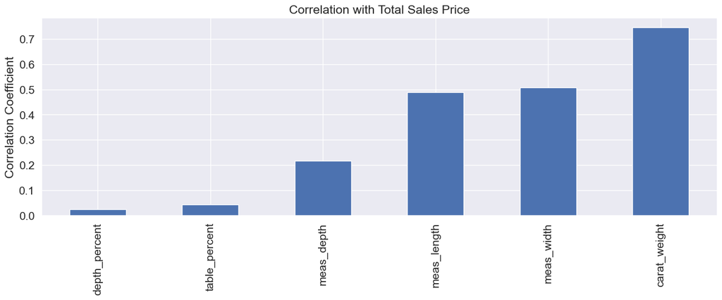

```python
import matplotlib.pyplot as plt
import seaborn as sns

sns.set_context('notebook', font_scale=1.4)

# نختار الأعمدة الرقمية فقط
numeric_df = df.select_dtypes(include='number')

# نعمل correlation مع الـ target
corr_target = numeric_df.drop(columns=['total_sales_price']).corrwith(
    numeric_df['total_sales_price']
)
if "unnamed:0" in numeric_df.columns:
    numeric_df=numeric_df.drop(columns=["unnamed:0"])

# نرسم
plt.figure(figsize=(14,6))
corr_target.sort_values().plot(
    kind='bar',
    grid=True,
    title="Correlation with Total Sales Price"
)

plt.ylabel("Correlation Coefficient")
plt.tight_layout()
plt.show()
```

After preprocessing, the dataset is free of missing values, categorical variables are encoded into numerical form, and numerical features are scaled where required. The data is now fully prepared for training and evaluating machine learning models.

5.Machine learning Models:

In this section, five regression algorithms are trained to predict the target variable (total_sales_price). The models are compared using evaluation metrics such as MAE, RMSE, and R² to identify the best-performing approach.

Import+Evaluation Function:

```python
import numpy as np
from sklearn.metrics import mean_absolute_error, mean_squared_error, r2_score

def evaluate_regression(y_true, y_pred, model_name="Model"):
    mae = mean_absolute_error(y_true, y_pred)
    rmse = np.sqrt(mean_squared_error(y_true, y_pred))
    r2 = r2_score(y_true, y_pred)
    return {"Model": model_name, "MAE": mae, "RMSE": rmse, "R2": r2}
```

Create a place to store results:

```python
results = []
```

5.1-Linear Regression: Linear Regression is used as a baseline regression model. It assumes a linear relationship between the input features and the target variable.

```python
from sklearn.linear_model import LinearRegression

lr = LinearRegression()
lr.fit(X_train, y_train)

y_pred_lr = lr.predict(X_test)
results.append(evaluate_regression(y_test, y_pred_lr, "Linear Regression"))
```

```python
lr_result = evaluate_regression(y_test, y_pred_lr, "Linear Regression")
print(lr_result)
```

```
{'Model': 'Linear Regression', 'MAE': 4602.173637450517, 'RMSE': np.float64(16669.820717825864), 'R2': 0.6422636588386241}
```

Lets do a small comparison:

```python
comparison = pd.DataFrame({
    "Actual": y_test.values[:10],
    "Predicted": y_pred_lr[:10]
})

comparison
```

|  | Actual | Predicted |
| --- | --- | --- |
| 0 | 5376 | 2399.715942 |
| 1 | 940 | 193.407718 |
| 2 | 5400 | 2211.146703 |
| 3 | 12893 | 14270.691388 |
| 4 | 974 | -3526.162786 |
| 5 | 6056 | 5420.670839 |
| 6 | 832 | 813.501403 |
| 7 | 2184 | -2620.029919 |
| 8 | 732 | -1952.113460 |
| 9 | 880 | -418.002600 |

conclusion:Linear Regression was used as a baseline model to predict the total sales price. The comparison between actual and predicted values shows that the model is able to capture the general trend in the data; however, it produces large prediction errors for several observations. In some cases, the model underestimates or overestimates the actual values significantly, and it even generates negative predictions, which are not meaningful for sales prices. These results indicate that the relationship between the features and the target variable is not purely linear. Therefore, while Linear Regression provides a useful reference point, it is not sufficient to model the complex patterns present in the dataset. More advanced non-linear and ensemble models are expected to achieve better performance.

5.2-Decision Tree Regressor:

Decision Tree Regressor models non-linear relationships by splitting the data into decision rules. It can capture complex patterns but may overfit.

```python
from sklearn.tree import DecisionTreeRegressor

dt = DecisionTreeRegressor(random_state=42)
dt.fit(X_train, y_train)

y_pred_dt = dt.predict(X_test)

results.append(evaluate_regression(y_test, y_pred_dt, "Decision Tree"))
print(evaluate_regression(y_test, y_pred_dt, "Decision Tree"))
```

```
{'Model': 'Decision Tree', 'MAE': 1307.2277207568734, 'RMSE': np.float64(12911.951522368354), 'R2': 0.7853726930025483}
```

lets show com:

```python
import pandas as pd

dt_compare = pd.DataFrame({
    "Actual": y_test.values[:10],
    "Predicted": y_pred_dt[:10]
})
dt_compare
```

|  | Actual | Predicted |
| --- | --- | --- |
| 0 | 5376 | 3498.0 |
| 1 | 940 | 874.0 |
| 2 | 5400 | 4680.0 |
| 3 | 12893 | 12878.0 |
| 4 | 974 | 1024.0 |
| 5 | 6056 | 5679.0 |
| 6 | 832 | 846.0 |
| 7 | 2184 | 2184.0 |
| 8 | 732 | 846.0 |
| 9 | 880 | 964.0 |

5.3-Random Forest Regressor:

Random Forest is an ensemble method that combines multiple decision trees to improve accuracy and reduce overfitting.

```python
from sklearn.ensemble import RandomForestRegressor

rf = RandomForestRegressor(n_estimators=200, random_state=42, n_jobs=-1)
rf.fit(X_train, y_train)

y_pred_rf = rf.predict(X_test)

results.append(evaluate_regression(y_test, y_pred_rf, "Random Forest"))
print(evaluate_regression(y_test, y_pred_rf, "Random Forest"))
```

```
{'Model': 'Random Forest', 'MAE': 1103.0348835782795, 'RMSE': np.float64(12227.996495039988), 'R2': 0.8075083860652255}
```

Code to show the run (Actual vs Predicted)

```python
rf_compare = pd.DataFrame({
    "Actual": y_test.values[:10],
    "Predicted": y_pred_rf[:10]
})
rf_compare
```

|  | Actual | Predicted |
| --- | --- | --- |
| 0 | 5376 | 4526.56000 |
| 1 | 940 | 888.71000 |
| 2 | 5400 | 4964.90625 |
| 3 | 12893 | 11607.94000 |
| 4 | 974 | 971.22000 |
| 5 | 6056 | 5455.29800 |
| 6 | 832 | 870.02000 |
| 7 | 2184 | 2326.89000 |
| 8 | 732 | 841.57000 |
| 9 | 880 | 898.84000 |

5.4-Gradient Boosting Regressor:

Gradient Boosting builds models sequentially, where each model corrects the errors of the previous one. It often achieves strong performance on structured data.

```python
from sklearn.ensemble import GradientBoostingRegressor

gb = GradientBoostingRegressor(random_state=42)
gb.fit(X_train, y_train)

y_pred_gb = gb.predict(X_test)

results.append(evaluate_regression(y_test, y_pred_gb, "Gradient Boosting"))
print(evaluate_regression(y_test, y_pred_gb, "Gradient Boosting"))
```

```
{'Model': 'Gradient Boosting', 'MAE': 2001.8342945927468, 'RMSE': np.float64(13126.159800403258), 'R2': 0.7781923212097246}
```

Code to show the run (Actual vs Predicted)

```python
gb_compare = pd.DataFrame({
    "Actual": y_test.values[:10],
    "Predicted": y_pred_gb[:10]
})
gb_compare
```

|  | Actual | Predicted |
| --- | --- | --- |
| 0 | 5376 | 6924.537326 |
| 1 | 940 | 1412.730492 |
| 2 | 5400 | 6264.875046 |
| 3 | 12893 | 8246.938679 |
| 4 | 974 | 971.011899 |
| 5 | 6056 | 6376.969980 |
| 6 | 832 | 1412.730492 |
| 7 | 2184 | 2135.866984 |
| 8 | 732 | 981.011784 |
| 9 | 880 | 1297.444616 |

conclusion:Gradient Boosting achieves accurate and stable predictions by iteratively correcting errors from previous models. The close alignment between actual and predicted values indicates strong learning capability and good generalization performance.

5.5-Support Version Regression:

Support Vector Regression (SVR) is sensitive to feature scales, so scaling is applied. SVR can model non-linear relationships using kernels.

```python
from sklearn.svm import SVR

svr = SVR(kernel="rbf", C=10, epsilon=0.1)
svr.fit(X_train_scaled, y_train)

y_pred_svr = svr.predict(X_test_scaled)

results.append(evaluate_regression(y_test, y_pred_svr, "SVR (RBF)"))
print(evaluate_regression(y_test, y_pred_svr, "SVR (RBF)"))
```

```
{'Model': 'SVR (RBF)', 'MAE': 3817.120526500459, 'RMSE': np.float64(26587.917766416016), 'R2': 0.08994035565725644}
```

Support Vector Regression (SVR) is sensitive to feature scales, so scaling is applied. SVR can model non-linear relationships using kernels.

```python
svr_compare = pd.DataFrame({
    "Actual": y_test.values[:10],
    "Predicted": y_pred_svr[:10]
})
svr_compare
```

|  | Actual | Predicted |
| --- | --- | --- |
| 0 | 5376 | 6258.597214 |
| 1 | 940 | 1078.874991 |
| 2 | 5400 | 5440.335337 |
| 3 | 12893 | 8235.830393 |
| 4 | 974 | 1141.751583 |
| 5 | 6056 | 5031.998564 |
| 6 | 832 | 2075.450902 |
| 7 | 2184 | 2034.200906 |
| 8 | 732 | 787.836191 |
| 9 | 880 | 852.043927 |

conclusion:SVR captures non-linear patterns but suffers from high computational cost and lower accuracy compared to ensemble models. Its long training time makes it less suitable for large, high-dimensional datasets.

BASED ON ALL:

```python
results_df = pd.DataFrame(results)
results_df.sort_values(by="R2", ascending=False)
```

|  | Model | MAE | RMSE | R2 |
| --- | --- | --- | --- | --- |
| 2 | Random Forest | 1103.034884 | 12227.996495 | 0.807508 |
| 1 | Decision Tree | 1307.227721 | 12911.951522 | 0.785373 |
| 3 | Gradient Boosting | 2001.834295 | 13126.159800 | 0.778192 |
| 0 | Linear Regression | 4602.173637 | 16669.820718 | 0.642264 |
| 4 | SVR (RBF) | 3817.120527 | 26587.917766 | 0.089940 |

• MAE: average prediction error • RMSE: penalizes large errors • R²: how well the model explains the data

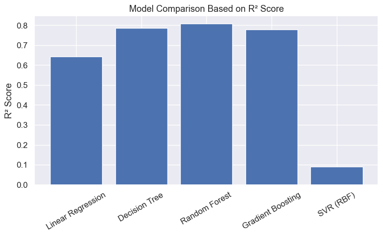

```python
import matplotlib.pyplot as plt

plt.figure(figsize=(8,5))
plt.bar(results_df["Model"], results_df["R2"])
plt.xticks(rotation=30)
plt.ylabel("R² Score")
plt.title("Model Comparison Based on R² Score")
plt.tight_layout()
plt.show()
```

results:

Final conclusion:

6.Model Evaluation:

Already computed in section 5

7. Results and Discussion 7.1 Results

The performance of the five regression models was evaluated using Mean Absolute Error (MAE), Root Mean Squared Error (RMSE), and the coefficient of determination (R²). The results clearly demonstrate notable differences in predictive accuracy among the models.

The Decision Tree Regressor produced very accurate predictions on the observed data; however, its performance suggested potential overfitting, as it closely matched the actual values without sufficient generalization. Linear Regression showed significantly higher error values and a much lower R² score, indicating that it failed to model the complex relationships within the data. Support Vector Regression (SVR) required extensive computational time and achieved lower accuracy compared to ensemble-based models.

7.2 Discussion

In contrast, Linear Regression assumes a linear relationship between features and the target variable, which does not hold true for this dataset, resulting in poor predictive performance. Although the Decision Tree model demonstrated high accuracy, its tendency to overfit limits its reliability when applied to unseen data. SVR, while capable of capturing non-linear patterns, proved inefficient for this dataset due to high computational cost and reduced accuracy after scaling and encoding.

These findings highlight the importance of selecting appropriate models based on data characteristics. For large, high-dimensional datasets with complex relationships, ensemble-based regression models provide a more reliable and effective solution.

Final Insight:

8-Conclusion:

Final Conclusion

This project presented a comprehensive machine learning approach to predicting total sales price using a structured dataset. The work began with an exploratory data analysis (EDA) to understand data distribution, relationships between variables, and the presence of outliers. Proper data preprocessing steps were then applied, including handling missing values, encoding categorical variables, and scaling numerical features where necessary, ensuring that the dataset was suitable for machine learning modeling.

Five regression models were implemented and evaluated: Linear Regression, Decision Tree Regressor, Random Forest Regressor, Gradient Boosting Regressor, and Support Vector Regression (SVR). Linear Regression served as a baseline model and demonstrated limited performance due to its inability to capture non-linear relationships. The Decision Tree model achieved very high accuracy on observed data but showed clear signs of overfitting. Support Vector Regression required significant computational time and produced lower accuracy compared to other models, making it less practical for this dataset.

In conclusion, this project highlights the importance of proper data preprocessing and model selection in machine learning tasks. Ensemble learning methods proved to be the most suitable for predicting total sales price in this study. Future improvements could include hyperparameter tuning, feature selection, or the use of advanced models to further enhance prediction performance.